# Risk Factor Analysis

## Outcome Variable

**Outcome Variable:** swasted

## Predictor Variables

**Intervention Variable:** nchldlt5

**Adjustment Set:**

- arm
- W_mage
- meducyrs
- feducyrs
- hhwealth_quart
- hfoodsec
- W_mhtcm
- W_mwtkg
- W_mbmi
- W_nrooms
- W_parity
- impfloor
- impsan
- safeh20
- delta_W_mage
- delta_meducyrs
- delta_feducyrs
- delta_hhwealth_quart
- delta_hfoodsec
- delta_W_mhtcm
- delta_W_mwtkg
- delta_W_mbmi
- delta_W_nrooms
- delta_W_parity
- delta_impfloor
- delta_impsan
- delta_safeh20

## Stratifying Variables

The analysis was stratified on these variable(s):

- agecat
- studyid
- country

## Data Summary

| agecat | studyid | country | nchldlt5 | swasted | n_cell | n |
| --- | --- | --- | --- | --- | --- | --- |
| Birth | IRC | INDIA | 1 | 0 | 59 | 343 |
| Birth | IRC | INDIA | 1 | 1 | 13 | 343 |
| Birth | IRC | INDIA | 2+ | 0 | 230 | 343 |
| Birth | IRC | INDIA | 2+ | 1 | 41 | 343 |
| Birth | JiVitA-3 | BANGLADESH | 1 | 0 | 10649 | 17991 |
| Birth | JiVitA-3 | BANGLADESH | 1 | 1 | 229 | 17991 |
| Birth | JiVitA-3 | BANGLADESH | 2+ | 0 | 6993 | 17991 |
| Birth | JiVitA-3 | BANGLADESH | 2+ | 1 | 120 | 17991 |
| Birth | NIH-Crypto | BANGLADESH | 1 | 0 | 468 | 707 |
| Birth | NIH-Crypto | BANGLADESH | 1 | 1 | 36 | 707 |
| Birth | NIH-Crypto | BANGLADESH | 2+ | 0 | 192 | 707 |
| Birth | NIH-Crypto | BANGLADESH | 2+ | 1 | 11 | 707 |
| Birth | PROVIDE | BANGLADESH | 1 | 0 | 373 | 532 |
| Birth | PROVIDE | BANGLADESH | 1 | 1 | 12 | 532 |
| Birth | PROVIDE | BANGLADESH | 2+ | 0 | 146 | 532 |
| Birth | PROVIDE | BANGLADESH | 2+ | 1 | 1 | 532 |
| 6 months | IRC | INDIA | 1 | 0 | 83 | 408 |
| 6 months | IRC | INDIA | 1 | 1 | 5 | 408 |
| 6 months | IRC | INDIA | 2+ | 0 | 303 | 408 |
| 6 months | IRC | INDIA | 2+ | 1 | 17 | 408 |
| 6 months | JiVitA-3 | BANGLADESH | 1 | 0 | 10728 | 16773 |
| 6 months | JiVitA-3 | BANGLADESH | 1 | 1 | 144 | 16773 |
| 6 months | JiVitA-3 | BANGLADESH | 2+ | 0 | 5816 | 16773 |
| 6 months | JiVitA-3 | BANGLADESH | 2+ | 1 | 85 | 16773 |
| 6 months | LCNI-5 | MALAWI | 1 | 0 | 390 | 811 |
| 6 months | LCNI-5 | MALAWI | 1 | 1 | 0 | 811 |
| 6 months | LCNI-5 | MALAWI | 2+ | 0 | 421 | 811 |
| 6 months | LCNI-5 | MALAWI | 2+ | 1 | 0 | 811 |
| 6 months | NIH-Crypto | BANGLADESH | 1 | 0 | 507 | 715 |
| 6 months | NIH-Crypto | BANGLADESH | 1 | 1 | 0 | 715 |
| 6 months | NIH-Crypto | BANGLADESH | 2+ | 0 | 208 | 715 |
| 6 months | NIH-Crypto | BANGLADESH | 2+ | 1 | 0 | 715 |
| 6 months | PROVIDE | BANGLADESH | 1 | 0 | 434 | 603 |
| 6 months | PROVIDE | BANGLADESH | 1 | 1 | 4 | 603 |
| 6 months | PROVIDE | BANGLADESH | 2+ | 0 | 164 | 603 |
| 6 months | PROVIDE | BANGLADESH | 2+ | 1 | 1 | 603 |
| 6 months | TanzaniaChild2 | TANZANIA, UNITED REPUBLIC OF | 1 | 0 | 1382 | 2019 |
| 6 months | TanzaniaChild2 | TANZANIA, UNITED REPUBLIC OF | 1 | 1 | 8 | 2019 |
| 6 months | TanzaniaChild2 | TANZANIA, UNITED REPUBLIC OF | 2+ | 0 | 625 | 2019 |
| 6 months | TanzaniaChild2 | TANZANIA, UNITED REPUBLIC OF | 2+ | 1 | 4 | 2019 |
| 24 months | IRC | INDIA | 1 | 0 | 86 | 409 |
| 24 months | IRC | INDIA | 1 | 1 | 3 | 409 |
| 24 months | IRC | INDIA | 2+ | 0 | 318 | 409 |
| 24 months | IRC | INDIA | 2+ | 1 | 2 | 409 |
| 24 months | JiVitA-3 | BANGLADESH | 1 | 0 | 5202 | 8593 |
| 24 months | JiVitA-3 | BANGLADESH | 1 | 1 | 232 | 8593 |
| 24 months | JiVitA-3 | BANGLADESH | 2+ | 0 | 3058 | 8593 |
| 24 months | JiVitA-3 | BANGLADESH | 2+ | 1 | 101 | 8593 |
| 24 months | LCNI-5 | MALAWI | 1 | 0 | 276 | 555 |
| 24 months | LCNI-5 | MALAWI | 1 | 1 | 1 | 555 |
| 24 months | LCNI-5 | MALAWI | 2+ | 0 | 278 | 555 |
| 24 months | LCNI-5 | MALAWI | 2+ | 1 | 0 | 555 |
| 24 months | NIH-Crypto | BANGLADESH | 1 | 0 | 353 | 514 |
| 24 months | NIH-Crypto | BANGLADESH | 1 | 1 | 4 | 514 |
| 24 months | NIH-Crypto | BANGLADESH | 2+ | 0 | 157 | 514 |
| 24 months | NIH-Crypto | BANGLADESH | 2+ | 1 | 0 | 514 |
| 24 months | PROVIDE | BANGLADESH | 1 | 0 | 419 | 579 |
| 24 months | PROVIDE | BANGLADESH | 1 | 1 | 5 | 579 |
| 24 months | PROVIDE | BANGLADESH | 2+ | 0 | 151 | 579 |
| 24 months | PROVIDE | BANGLADESH | 2+ | 1 | 4 | 579 |
| 24 months | TanzaniaChild2 | TANZANIA, UNITED REPUBLIC OF | 1 | 0 | 5 | 6 |
| 24 months | TanzaniaChild2 | TANZANIA, UNITED REPUBLIC OF | 1 | 1 | 0 | 6 |
| 24 months | TanzaniaChild2 | TANZANIA, UNITED REPUBLIC OF | 2+ | 0 | 1 | 6 |
| 24 months | TanzaniaChild2 | TANZANIA, UNITED REPUBLIC OF | 2+ | 1 | 0 | 6 |

The following strata were considered:

- agecat: 24 months, studyid: IRC, country: INDIA
- agecat: 24 months, studyid: JiVitA-3, country: BANGLADESH
- agecat: 24 months, studyid: LCNI-5, country: MALAWI
- agecat: 24 months, studyid: NIH-Crypto, country: BANGLADESH
- agecat: 24 months, studyid: PROVIDE, country: BANGLADESH
- agecat: 24 months, studyid: TanzaniaChild2, country: TANZANIA, UNITED REPUBLIC OF
- agecat: 6 months, studyid: IRC, country: INDIA
- agecat: 6 months, studyid: JiVitA-3, country: BANGLADESH
- agecat: 6 months, studyid: LCNI-5, country: MALAWI
- agecat: 6 months, studyid: NIH-Crypto, country: BANGLADESH
- agecat: 6 months, studyid: PROVIDE, country: BANGLADESH
- agecat: 6 months, studyid: TanzaniaChild2, country: TANZANIA, UNITED REPUBLIC OF
- agecat: Birth, studyid: IRC, country: INDIA
- agecat: Birth, studyid: JiVitA-3, country: BANGLADESH
- agecat: Birth, studyid: NIH-Crypto, country: BANGLADESH
- agecat: Birth, studyid: PROVIDE, country: BANGLADESH

### Dropped Strata

Some strata were dropped due to rare outcomes:

- agecat: Birth, studyid: PROVIDE, country: BANGLADESH
- agecat: 6 months, studyid: LCNI-5, country: MALAWI
- agecat: 6 months, studyid: NIH-Crypto, country: BANGLADESH
- agecat: 6 months, studyid: PROVIDE, country: BANGLADESH
- agecat: 6 months, studyid: TanzaniaChild2, country: TANZANIA, UNITED REPUBLIC OF
- agecat: 24 months, studyid: IRC, country: INDIA
- agecat: 24 months, studyid: LCNI-5, country: MALAWI
- agecat: 24 months, studyid: NIH-Crypto, country: BANGLADESH
- agecat: 24 months, studyid: PROVIDE, country: BANGLADESH
- agecat: 24 months, studyid: TanzaniaChild2, country: TANZANIA, UNITED REPUBLIC OF

## Methods Detail

We’re interested in the causal parameters $E[Y_a]$ for all values of $a \in \mathcal{A}$. These parameters represent the mean outcome if, possibly contrary to fact, we intervened to set all units to have $A=a$. Under the randomization and positivity assumptions, these are identified by the statistical parameters $\psi_a=E_W[E_{Y|A,W}(Y|A=a,W)]$. In addition, we’re interested in the mean of $Y$, $E[Y]$ under no intervention (the observed mean). We will estimate these parameters by using SuperLearner to fit the relevant likelihood factors – $E_{Y|A,W}(Y|A=a,W)$ and $p(A=a|W)$, and then updating our likelihood fit using a joint TMLE.

For unadjusted analyses ($W=\{\}$), initial likelihoods were estimated using Lrnr_glm to estimate the simple $E(Y|A)$ and Lrnr_mean to estimate $p(A)$. For adjusted analyses, a small library containing Lrnr_glmnet, Lrnr_xgboost, and Lrnr_mean was used.

Having estimated these parameters, we will then use the delta method to estimate relative risks and attributable risks relative to a prespecified baseline level of $A$.

# Results Detail

## Results Plots

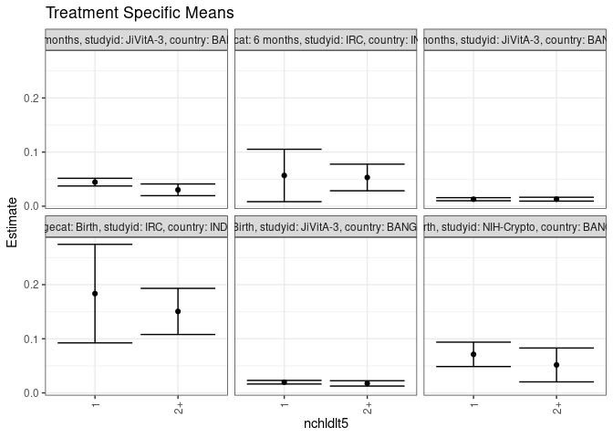

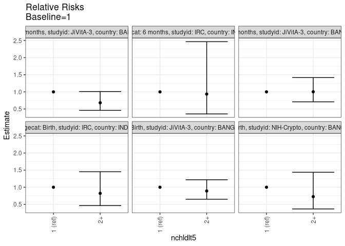

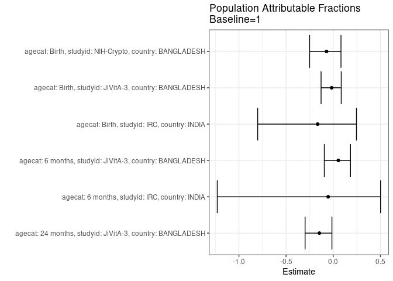

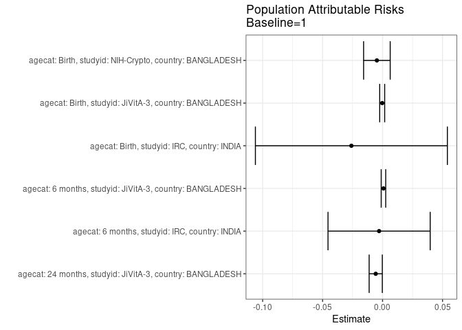

## Results Table

### Parameter: TSM

| agecat | studyid | country | intervention_level | baseline_level | estimate | ci_lower | ci_upper |
| --- | --- | --- | --- | --- | --- | --- | --- |
| Birth | IRC | INDIA | 1 | NA | 0.1834360 | 0.0923680 | 0.2745040 |
| Birth | IRC | INDIA | 2+ | NA | 0.1505327 | 0.1079031 | 0.1931624 |
| Birth | JiVitA-3 | BANGLADESH | 1 | NA | 0.0197178 | 0.0163526 | 0.0230830 |
| Birth | JiVitA-3 | BANGLADESH | 2+ | NA | 0.0175491 | 0.0126297 | 0.0224686 |
| Birth | NIH-Crypto | BANGLADESH | 1 | NA | 0.0712072 | 0.0486539 | 0.0937604 |
| Birth | NIH-Crypto | BANGLADESH | 2+ | NA | 0.0516346 | 0.0203294 | 0.0829397 |
| 6 months | IRC | INDIA | 1 | NA | 0.0568182 | 0.0083919 | 0.1052445 |
| 6 months | IRC | INDIA | 2+ | NA | 0.0531250 | 0.0285212 | 0.0777288 |
| 6 months | JiVitA-3 | BANGLADESH | 1 | NA | 0.0129114 | 0.0100833 | 0.0157395 |
| 6 months | JiVitA-3 | BANGLADESH | 2+ | NA | 0.0129456 | 0.0093812 | 0.0165101 |
| 24 months | JiVitA-3 | BANGLADESH | 1 | NA | 0.0444606 | 0.0373317 | 0.0515895 |
| 24 months | JiVitA-3 | BANGLADESH | 2+ | NA | 0.0302679 | 0.0194442 | 0.0410916 |

### Parameter: E(Y)

| agecat | studyid | country | intervention_level | baseline_level | estimate | ci_lower | ci_upper |
| --- | --- | --- | --- | --- | --- | --- | --- |
| Birth | IRC | INDIA | NA | NA | 0.1574344 | 0.1188345 | 0.1960344 |
| Birth | JiVitA-3 | BANGLADESH | NA | NA | 0.0193986 | 0.0169868 | 0.0218104 |
| Birth | NIH-Crypto | BANGLADESH | NA | NA | 0.0664781 | 0.0481022 | 0.0848539 |
| 6 months | IRC | INDIA | NA | NA | 0.0539216 | 0.0319786 | 0.0758646 |
| 6 months | JiVitA-3 | BANGLADESH | NA | NA | 0.0136529 | 0.0115796 | 0.0157262 |
| 24 months | JiVitA-3 | BANGLADESH | NA | NA | 0.0387525 | 0.0344262 | 0.0430787 |

### Parameter: RR

| agecat | studyid | country | intervention_level | baseline_level | estimate | ci_lower | ci_upper |
| --- | --- | --- | --- | --- | --- | --- | --- |
| Birth | IRC | INDIA | 1 | 1 | 1.0000000 | 1.0000000 | 1.000000 |
| Birth | IRC | INDIA | 2+ | 1 | 0.8206280 | 0.4634412 | 1.453108 |
| Birth | JiVitA-3 | BANGLADESH | 1 | 1 | 1.0000000 | 1.0000000 | 1.000000 |
| Birth | JiVitA-3 | BANGLADESH | 2+ | 1 | 0.8900132 | 0.6499617 | 1.218723 |
| Birth | NIH-Crypto | BANGLADESH | 1 | 1 | 1.0000000 | 1.0000000 | 1.000000 |
| Birth | NIH-Crypto | BANGLADESH | 2+ | 1 | 0.7251317 | 0.3656191 | 1.438152 |
| 6 months | IRC | INDIA | 1 | 1 | 1.0000000 | 1.0000000 | 1.000000 |
| 6 months | IRC | INDIA | 2+ | 1 | 0.9350000 | 0.3544411 | 2.466489 |
| 6 months | JiVitA-3 | BANGLADESH | 1 | 1 | 1.0000000 | 1.0000000 | 1.000000 |
| 6 months | JiVitA-3 | BANGLADESH | 2+ | 1 | 1.0026514 | 0.7092020 | 1.417523 |
| 24 months | JiVitA-3 | BANGLADESH | 1 | 1 | 1.0000000 | 1.0000000 | 1.000000 |
| 24 months | JiVitA-3 | BANGLADESH | 2+ | 1 | 0.6807814 | 0.4589787 | 1.009771 |

### Parameter: PAR

| agecat | studyid | country | intervention_level | baseline_level | estimate | ci_lower | ci_upper |
| --- | --- | --- | --- | --- | --- | --- | --- |
| Birth | IRC | INDIA | 1 | NA | -0.0260016 | -0.1060455 | 0.0540423 |
| Birth | JiVitA-3 | BANGLADESH | 1 | NA | -0.0003192 | -0.0023923 | 0.0017538 |
| Birth | NIH-Crypto | BANGLADESH | 1 | NA | -0.0047291 | -0.0158177 | 0.0063595 |
| 6 months | IRC | INDIA | 1 | NA | -0.0028966 | -0.0454993 | 0.0397060 |
| 6 months | JiVitA-3 | BANGLADESH | 1 | NA | 0.0007415 | -0.0011421 | 0.0026251 |
| 24 months | JiVitA-3 | BANGLADESH | 1 | NA | -0.0057081 | -0.0111967 | -0.0002195 |

### Parameter: PAF

| agecat | studyid | country | intervention_level | baseline_level | estimate | ci_lower | ci_upper |
| --- | --- | --- | --- | --- | --- | --- | --- |
| Birth | IRC | INDIA | 1 | NA | -0.1651584 | -0.8010493 | 0.2462205 |
| Birth | JiVitA-3 | BANGLADESH | 1 | NA | -0.0164573 | -0.1288870 | 0.0847752 |
| Birth | NIH-Crypto | BANGLADESH | 1 | NA | -0.0711375 | -0.2502698 | 0.0823297 |
| 6 months | IRC | INDIA | 1 | NA | -0.0537190 | -1.2297282 | 0.5020363 |
| 6 months | JiVitA-3 | BANGLADESH | 1 | NA | 0.0543113 | -0.0946933 | 0.1830340 |
| 24 months | JiVitA-3 | BANGLADESH | 1 | NA | -0.1472965 | -0.2983444 | -0.0138214 |